# product_reviews_sentiment

### Product Reviews Sentiment Analysis

### Business Context

In the rapidly evolving landscape of e-commerce, customer reviews play a pivotal role in shaping the perception of products and influencing purchasing decisions. All businesses recognize the significance of understanding customer sentiment and extracting valuable insights from the vast pool of customer reviews to drive decisions. The inability to actively track customer feedback can result in significant challenges for businesses. Negative sentiments expressed by customers become crucial to track and resolve as they can lead to several detrimental effects, including: 1. Customer Churn: Unaddressed negative sentiment can lead to customer dissatisfaction and the potential loss of loyal customers. This may result in customers opting for alternative platforms for their future purchases, impacting long-term revenue and market share. 2. Reputation Damage: The persistence of negative sentiment, if not effectively managed, can tarnish the reputation of the business. Potential customers may be dissuaded from making purchases on the platform due to concerns raised in negative reviews, affecting brand loyalty and trust. 3. Financial Implications: Negative sentiment can lead to a decline in sales, impacting profitability. Discouraged by negative feedback, potential customers may choose competitors, resulting in direct financial repercussions for the company.

### Problem Definition

A rising e-commerce platform in the space of electronic gadgets captures customer feedback through different channels, such as product review forms, surveys, and more. In addition, they also capture customer feedback from social media platforms. After witnessing a 200% growth in their customer base in the last three years, they are now experiencing a substantial upswing in the number of customer feedbacks received, with a noteworthy increase of ~25% over the past six months. As they were previously monitoring customer feedback manually, this surge in customer feedback presents a multifaceted challenge for the business as the volume of reviews has surpassed the manual capacity to track and analyze effectively. Recognizing the need for a proactive and scalable solution, the organization seeks to employ artificial intelligence (AI) to aid them. The primary objective is to develop an AI solution that can automatically assess and categorize customer sentiments as negative, positive, or neutral by parsing and analyzing product reviews. As a Data Scientist, you are provided with the reviews shared by customers regarding their experience with the product along with the manually labeled sentiments of the reviews and asked to analyze the data and build a predictive model that can parse the customer reviews and predict the sentiment of the customer.

## Importing the necessary libraries

```python
# to read and manipulate the data
import pandas as pd
import numpy as np
pd.set_option('max_colwidth', None)    # setting column to the maximum column width as per the data

# to visualise data
import matplotlib.pyplot as plt
import seaborn as sns

# to use regular expressions for manipulating text data
import re

# To potentially exit if file not found or columns missing
import sys

# to load the natural language toolkit
import nltk
nltk.download('stopwords')    # loading the stopwords
nltk.download('wordnet')    # loading the wordnet module that is used in stemming

# to remove common stop words
from nltk.corpus import stopwords

# to perform stemming
from nltk.stem.porter import PorterStemmer

# to create Bag of Words
from sklearn.feature_extraction.text import CountVectorizer

# to import Word2Vec
from gensim.models import Word2Vec

# to split data into train and test sets
from sklearn.model_selection import train_test_split

# to build a Random Forest model
from sklearn.ensemble import RandomForestClassifier

# to compute metrics to evaluate the model
from sklearn import metrics
from sklearn.metrics import accuracy_score, classification_report
from sklearn.metrics import confusion_matrix

# To tune different models
from sklearn.model_selection import GridSearchCV
```

### Data Dictionary

- **Product_ID**: An exclusive identification number for each product
- **Product_Reviews**: Insights and opinions shared by customers about the product
- **Sentiment**: Sentiment associated with the product review, indicating whether the review expresses a positive, negative, or neutral sentiment

```python
input_csv_filename = 'original_dataset.csv'
print(f"Attempting to load data from: {input_csv_filename}")

try:
    df_original = pd.read_csv(input_csv_filename)
    print(f"Successfully loaded '{input_csv_filename}'.")

    # Display basic information
    print("\n--- Data Overview ---")
    print(f"Shape of the dataset (rows, columns): {df_original.shape}")

    print("\n--- Column Headers (Column Names) ---")
    print(df_original.columns.tolist()) # Display all column names as a list

    print("\n--- First 5 Rows (for context) ---")
    print(df_original.head())

    print("\n--- Data Types and Non-Null Counts ---")
    df_original.info()

except FileNotFoundError:
    print(f"\nError: Input file '{input_csv_filename}' not found.")
    print("Please ensure the file exists in the correct directory and the filename is spelled correctly.")
    # Set df_original to None so the next cell knows loading failed
    df_original = None
except Exception as e:
    print(f"\nAn error occurred while loading '{input_csv_filename}': {e}")
    # Set df_original to None so the next cell knows loading failed
    df_original = None
```

```
Attempting to load data from: original_dataset.csv
Successfully loaded 'original_dataset.csv'.

--- Data Overview ---
Shape of the dataset (rows, columns): (1597, 27)

--- Column Headers (Column Names) ---
['id', 'asins', 'brand', 'categories', 'colors', 'dateAdded', 'dateUpdated', 'dimension', 'ean', 'keys', 'manufacturer', 'manufacturerNumber', 'name', 'prices', 'reviews.date', 'reviews.doRecommend', 'reviews.numHelpful', 'reviews.rating', 'reviews.sourceURLs', 'reviews.text', 'reviews.title', 'revi…

--- First 5 Rows (for context) ---
                     id       asins   brand                  categories  \
0  AVpe7AsMilAPnD_xQ78G  B00QJDU3KY  Amazon  Amazon Devices,mazon.co.uk
1  AVpe7AsMilAPnD_xQ78G  B00QJDU3KY  Amazon  Amazon Devices,mazon.co.uk
2  AVpe7AsMilAPnD_xQ78G  B00QJDU3KY  Amazon  Amazon Devices,mazon.co.uk
3  AVpe7AsMilAPnD_xQ78G  B00QJDU3KY  Amazon  Amazon Devices,mazon.co.uk
4  AVpe7AsMilAPnD_xQ78G  B00QJDU3KY  Amazon  Amazon Devices,mazon.co.uk

  colors             dateAdded           dateUpdated  \
0    NaN  2016-03-08T20:21:53Z  2017-07-18T23:52:58Z
1    NaN  2016-03-08T20:21:53Z  2017-07-18T23:52:58Z
2    NaN  2016-03-08T20:21:53Z  2017-07-18T23:52:58Z
3    NaN  2016-03-08T20:21:53Z  2017-07-18T23:52:58Z
4    NaN  2016-03-08T20:21:53Z  2017-07-18T23:52:58Z

                  dimension  ean                         keys  ...  \
0  169 mm x 117 mm x 9.1 mm  NaN  kindlepaperwhite/b00qjdu3ky  ...
1  169 mm x 117 mm x 9.1 mm  NaN  kindlepaperwhite/b00qjdu3ky  ...
2  169 mm x 117 mm x 9.1 mm  NaN  kindlepaperwhite/b00qjdu3ky  ...
3  169 mm x 117 mm x 9.1 mm  NaN  kindlepaperwhite/b00qjdu3ky  ...
4  169 mm x 117 mm x 9.1 mm  NaN  kindlepaperwhite/b00qjdu3ky  ...

  reviews.rating  \
0            5.0
1            5.0
2            4.0
3            5.0
4            5.0

                                                                                                                                                              reviews.sourceURLs  \
0  https://www.amazon.com/Kindle-Paperwhite-High-Resolution-Display-Built/dp/B00QJDU3KY/ref=lp_6669702011_1_7/132-1677641-8459202?s=amazon-devices&ie=UTF8&qid=1498832761&sr=1-7
```

[output cut: 48 more lines]

```
 14  reviews.date          1217 non-null   object
 15  reviews.doRecommend   539 non-null    object
 16  reviews.numHelpful    900 non-null    float64
 17  reviews.rating        1177 non-null   float64
 18  reviews.sourceURLs    1597 non-null   object
 19  reviews.text          1597 non-null   object
 20  reviews.title         1580 non-null   object
 21  reviews.userCity      0 non-null      float64
 22  reviews.userProvince  0 non-null      float64
 23  reviews.username      1580 non-null   object
 24  sizes                 0 non-null      float64
 25  upc                   898 non-null    float64
 26  weight                686 non-null    object
dtypes: float64(7), object(20)
memory usage: 337.0+ KB
```

```python
original_id_col = 'id'
original_review_col = 'reviews.text'
original_rating_col = 'reviews.rating'

#Renaming the columns for the prepartion of Data Dictionary
output_id_col = 'Product_ID'
output_review_col = 'Product_Reviews'
output_sentiment_col = 'Sentiment'
output_csv_filename = 'Data_Dictionary.csv'

# Checking if df_original was loaded successfully
if 'df_original' in locals() and df_original is not None:
    print("Proceeding with data preparation using the loaded 'df_original' DataFrame.")

    #Verify required columns exist
    required_original_cols = [original_id_col, original_review_col, original_rating_col]
    missing_cols = [col for col in required_original_cols if col not in df_original.columns]

    if missing_cols:
        print(f"\nError: The following required columns are missing from the original data: {missing_cols}")
        print(f"Available columns are: {df_original.columns.tolist()}")
        print("Please correct the column names in the configuration section of this cell and rerun Cell 1 if needed.")
    else:
        print(f"\nFound required columns: {required_original_cols}")

        # Select the necessary columns
        df_selected = df_original[required_original_cols].copy()
        initial_rows = len(df_selected)
        print(f"Selected relevant columns. Initial row count: {initial_rows}")

        # --- Data Cleaning Step: Drop rows with missing ratings ---
        print(f"\nChecking for and removing rows with missing values in '{original_rating_col}'...")
        # Report number of NaNs before dropping
        nan_count = df_selected[original_rating_col].isnull().sum()
        if nan_count > 0:
             print(f"Found {nan_count} missing values (NaNs) in '{original_rating_col}'.")

        # Drop rows where the specified rating column is NaN
        df_selected.dropna(subset=[original_rating_col], inplace=True)
        rows_after_drop = len(df_selected)
        rows_dropped = initial_rows - rows_after_drop
        print(f"Removed {rows_dropped} rows due to missing ratings.")
        print(f"Row count after cleaning: {rows_after_drop}")

        # Check if any rows remain after cleaning
        if rows_after_drop == 0:
            print("\nWarning: All rows were dropped due to missing ratings. No data left to process.")
        else:
            def map_sentiment(rating):
                try:

                    numeric_rating = pd.to_numeric(rating, errors='coerce')

                    if pd.isna(numeric_rating):

                        return np.nan
                    elif numeric_rating > 3:
                        return 'POSITIVE'
                    elif numeric_rating == 3:
                        return 'NEUTRAL'
                    elif numeric_rating < 3:
                        return 'NEGATIVE'
                    else:
                         return np.nan
                except Exception as e:
                    # Catch any other unexpected error during processing a rating
                    print(f"Warning: Unexpected error processing rating '{rating}': {e}")
                    return np.nan

            # Create the new 'Sentiment' column
            print(f"\nCreating '{output_sentiment_col}' column based on '{original_rating_col}'...")
            df_selected[output_sentiment_col] = df_selected[original_rating_col].apply(map_sentiment)
            print("Done creating Sentiment column.")

            #Drop rows where sentiment mapping failed
            invalid_sentiment_count = df_selected[output_sentiment_col].isnull().sum()
            if invalid_sentiment_count > 0:
                print(f"Found {invalid_sentiment_count} rows where rating could not be mapped to sentiment (e.g., non-numeric). Removing these rows.")
                df_selected.dropna(subset=[output_sentiment_col], inplace=True)
                print(f"Row count after removing invalid sentiment mappings: {len(df_selected)}")


            # Check again if any rows remain
            if len(df_selected) == 0:
                 print("\nWarning: All remaining rows were dropped due to invalid ratings for sentiment mapping. No data left to save.")
            else:
                # Rename columns to the desired output names
                df_final = df_selected.rename(columns={
                    original_id_col: output_id_col,
                    original_review_col: output_review_col
                })
                print(f"\nRenamed columns to: {[output_id_col, output_review_col, output_sentiment_col]}")

                # Make sure sentiment column is included if it exists after potential drops
                final_columns = [output_id_col, output_review_col, output_sentiment_col]
                if output_sentiment_col not in df_final.columns:
                     print(f"Warning: '{output_sentiment_col}' column not found in final DataFrame. Skipping selection.")

                df_final = df_final[final_columns]

                print(f"\n--- Value counts for the final '{output_sentiment_col}' column ---")
                print(df_final[output_sentiment_col].value_counts(dropna=False)) # dropna=False verifies no NaNs remain

                # Save the result to the new CSV
                try:
                    # Use encoding='utf-8' for better compatibility with text data
                    df_final.to_csv(output_csv_filename, index=False, encoding='utf-8')
                    print(f"\nSuccessfully created and saved the prepared data to '{output_csv_filename}'.")
                except Exception as e:
                    print(f"\nError: Could not save the file '{output_csv_filename}'. Reason: {e}")

else:
    print("\nError: 'df_original' DataFrame not found or was not loaded successfully.")
    print("Please make sure you have successfully run Cell 1 to load the data before running this cell.")
```

```
Proceeding with data preparation using the loaded 'df_original' DataFrame.

Found required columns: ['id', 'reviews.text', 'reviews.rating']
Selected relevant columns. Initial row count: 1597

Checking for and removing rows with missing values in 'reviews.rating'...
Found 420 missing values (NaNs) in 'reviews.rating'.
Removed 420 rows due to missing ratings.
Row count after cleaning: 1177

Creating 'Sentiment' column based on 'reviews.rating'...
Done creating Sentiment column.

Renamed columns to: ['Product_ID', 'Product_Reviews', 'Sentiment']

--- Value counts for the final 'Sentiment' column ---
Sentiment
POSITIVE    977
NEUTRAL     124
NEGATIVE     76
Name: count, dtype: int64

Successfully created and saved the prepared data to 'Data_Dictionary.csv'.
```

## Loading the dataset

```python
# loading data into a pandas dataframe
reviews = pd.read_csv("Data_Dictionary.csv")
```

```python
# creating a copy of the data
data = reviews.copy()
```

### Checking the first five rows of the data

```python
data.head(5)
```

|  | Product_ID | Product_Reviews | Sentiment |
| --- | --- | --- | --- |
| 0 | AVpe7AsMilAPnD_xQ78G | I initially had trouble deciding between the paperwhite and the voyage because reviews more or less said the same thing: the paperwhite is great, but if you have spending money, go for the voyage.Fort… | POSITIVE |
| 1 | AVpe7AsMilAPnD_xQ78G | Allow me to preface this with a little history. I am (was) a casual reader who owned a Nook Simple Touch from 2011. I've read the Harry Potter series, Girl with the Dragon Tattoo series, 1984, Brave N… | POSITIVE |
| 2 | AVpe7AsMilAPnD_xQ78G | I am enjoying it so far. Great for reading. Had the original Fire since 2012. The Fire used to make my eyes hurt if I read too long. Haven't experienced that with the Paperwhite yet. | POSITIVE |
| 3 | AVpe7AsMilAPnD_xQ78G | I bought one of the first Paperwhites and have been very pleased with it its been a constant companion and I suppose Ive read, on average, a book every three days for the past however many years on it… | POSITIVE |
| 4 | AVpe7AsMilAPnD_xQ78G | I have to say upfront - I don't like coroporate, hermetically closed stuff like anything by Apple or in this case, Amazon. I like having devices on which I can put anything I want and use it. But...I … | POSITIVE |

### Checking the shape of the dataset

```python
data.shape
```

```
(1177, 3)
```

### Checking for Missing Values

```python
data.isnull().sum()
```

```
Product_ID         0
Product_Reviews    0
Sentiment          0
dtype: int64
```

```python
# checking for duplicate values
data.duplicated().sum()
```

```
172
```

```python
# dropping duplicate values
data = data.drop_duplicates()

data.duplicated().sum()
```

```
0
```

## Exploratory Data Analysis (EDA)

```python
 # function to create labeled barplots

def labeled_barplot(data, feature, perc=False, n=None):
    """
    Barplot with percentage at the top

    data: dataframe
    feature: dataframe column
    perc: whether to display percentages instead of count (default is False)
    n: displays the top n category levels (default is None, i.e., display all levels)
    """

    total = len(data[feature])  # length of the column
    count = data[feature].nunique()
    if n is None:
        plt.figure(figsize=(count + 1, 5))
    else:
        plt.figure(figsize=(n + 1, 5))

    plt.xticks(rotation=90, fontsize=15)
    ax = sns.countplot(
        data=data,
        x=feature,
        palette="Paired",
        order=data[feature].value_counts().index[:n].sort_values(),
    )

    for p in ax.patches:
        if perc == True:
            label = "{:.1f}%".format(
                100 * p.get_height() / total
            )  # percentage of each class of the category
        else:
            label = p.get_height()  # count of each level of the category

        x = p.get_x() + p.get_width() / 2  # width of the plot
        y = p.get_height()  # height of the plot

        ax.annotate(
            label,
            (x, y),
            ha="center",
            va="center",
            size=12,
            xytext=(0, 5),
            textcoords="offset points",
        )  # annotate the percentage

    plt.show()  # show the plot
```

#### Distribution of sentiments

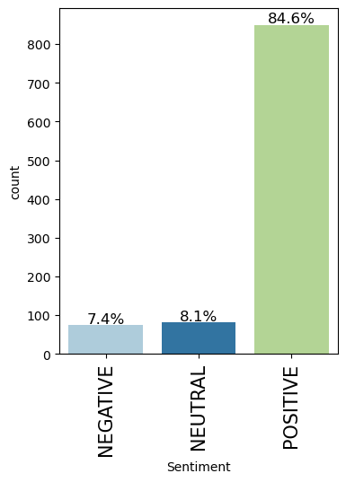

```python
labeled_barplot(data, "Sentiment", perc=True)
```

## Text Preprocessing

### Removing special characters from the text

```python
# defining a function to remove special characters
def remove_special_characters(text):
    # Defining the regex pattern to match non-alphanumeric characters
    pattern = '[^A-Za-z0-9]+'

    # Finding the specified pattern and replacing non-alphanumeric characters with a blank string
    new_text = ''.join(re.sub(pattern, ' ', text))

    return new_text
```

```python
# Applying the function to remove special characters
data['cleaned_text'] = data['Product_Reviews'].apply(remove_special_characters)
```

```python
# checking a couple of instances of cleaned data
data.loc[0:3, ['Product_Reviews','cleaned_text']]
```

|  | Product_Reviews | cleaned_text |
| --- | --- | --- |
| 0 | I initially had trouble deciding between the paperwhite and the voyage because reviews more or less said the same thing: the paperwhite is great, but if you have spending money, go for the voyage.Fort… | I initially had trouble deciding between the paperwhite and the voyage because reviews more or less said the same thing the paperwhite is great but if you have spending money go for the voyage Fortuna… |
| 1 | Allow me to preface this with a little history. I am (was) a casual reader who owned a Nook Simple Touch from 2011. I've read the Harry Potter series, Girl with the Dragon Tattoo series, 1984, Brave N… | Allow me to preface this with a little history I am was a casual reader who owned a Nook Simple Touch from 2011 I ve read the Harry Potter series Girl with the Dragon Tattoo series 1984 Brave New Worl… |
| 2 | I am enjoying it so far. Great for reading. Had the original Fire since 2012. The Fire used to make my eyes hurt if I read too long. Haven't experienced that with the Paperwhite yet. | I am enjoying it so far Great for reading Had the original Fire since 2012 The Fire used to make my eyes hurt if I read too long Haven t experienced that with the Paperwhite yet |
| 3 | I bought one of the first Paperwhites and have been very pleased with it its been a constant companion and I suppose Ive read, on average, a book every three days for the past however many years on it… | I bought one of the first Paperwhites and have been very pleased with it its been a constant companion and I suppose Ive read on average a book every three days for the past however many years on it I… |

### Lowercasing

```python
# changing the case of the text data to lower case
data['cleaned_text'] = data['cleaned_text'].str.lower()
```

```python
# checking a couple of instances of cleaned data
data.loc[0:3, ['Product_Reviews','cleaned_text']]
```

|  | Product_Reviews | cleaned_text |
| --- | --- | --- |
| 0 | I initially had trouble deciding between the paperwhite and the voyage because reviews more or less said the same thing: the paperwhite is great, but if you have spending money, go for the voyage.Fort… | i initially had trouble deciding between the paperwhite and the voyage because reviews more or less said the same thing the paperwhite is great but if you have spending money go for the voyage fortuna… |
| 1 | Allow me to preface this with a little history. I am (was) a casual reader who owned a Nook Simple Touch from 2011. I've read the Harry Potter series, Girl with the Dragon Tattoo series, 1984, Brave N… | allow me to preface this with a little history i am was a casual reader who owned a nook simple touch from 2011 i ve read the harry potter series girl with the dragon tattoo series 1984 brave new worl… |
| 2 | I am enjoying it so far. Great for reading. Had the original Fire since 2012. The Fire used to make my eyes hurt if I read too long. Haven't experienced that with the Paperwhite yet. | i am enjoying it so far great for reading had the original fire since 2012 the fire used to make my eyes hurt if i read too long haven t experienced that with the paperwhite yet |
| 3 | I bought one of the first Paperwhites and have been very pleased with it its been a constant companion and I suppose Ive read, on average, a book every three days for the past however many years on it… | i bought one of the first paperwhites and have been very pleased with it its been a constant companion and i suppose ive read on average a book every three days for the past however many years on it i… |

### Removing extra whitespace

```python
# removing extra whitespaces from the text
data['cleaned_text'] = data['cleaned_text'].str.strip()
```

```python
# checking a couple of instances of cleaned data
data.loc[0:3, ['Product_Reviews','cleaned_text']]
```

|  | Product_Reviews | cleaned_text |
| --- | --- | --- |
| 0 | I initially had trouble deciding between the paperwhite and the voyage because reviews more or less said the same thing: the paperwhite is great, but if you have spending money, go for the voyage.Fort… | i initially had trouble deciding between the paperwhite and the voyage because reviews more or less said the same thing the paperwhite is great but if you have spending money go for the voyage fortuna… |
| 1 | Allow me to preface this with a little history. I am (was) a casual reader who owned a Nook Simple Touch from 2011. I've read the Harry Potter series, Girl with the Dragon Tattoo series, 1984, Brave N… | allow me to preface this with a little history i am was a casual reader who owned a nook simple touch from 2011 i ve read the harry potter series girl with the dragon tattoo series 1984 brave new worl… |
| 2 | I am enjoying it so far. Great for reading. Had the original Fire since 2012. The Fire used to make my eyes hurt if I read too long. Haven't experienced that with the Paperwhite yet. | i am enjoying it so far great for reading had the original fire since 2012 the fire used to make my eyes hurt if i read too long haven t experienced that with the paperwhite yet |
| 3 | I bought one of the first Paperwhites and have been very pleased with it its been a constant companion and I suppose Ive read, on average, a book every three days for the past however many years on it… | i bought one of the first paperwhites and have been very pleased with it its been a constant companion and i suppose ive read on average a book every three days for the past however many years on it i… |

### Removing stopwords

- The idea with stop word removal is to **exclude words that appear frequently throughout** all the documents in the corpus.
- Pronouns and articles are typically categorized as stop words.
- The `NLTK` library has an in-built list of stop words and it can utilize that list to remove the stop words from a dataset.

```python
# defining a function to remove stop words using the NLTK library
def remove_stopwords(text):
    # Split text into separate words
    words = text.split()

    # Removing English language stopwords
    new_text = ' '.join([word for word in words if word not in stopwords.words('english')])

    return new_text
```

```python
# Applying the function to remove stop words using the NLTK library
data['cleaned_text_without_stopwords'] = data['cleaned_text'].apply(remove_stopwords)
```

```python
# checking a couple of instances of cleaned data
data.loc[0:3,['cleaned_text','cleaned_text_without_stopwords']]
```

|  | cleaned_text | cleaned_text_without_stopwords |
| --- | --- | --- |
| 0 | i initially had trouble deciding between the paperwhite and the voyage because reviews more or less said the same thing the paperwhite is great but if you have spending money go for the voyage fortuna… | initially trouble deciding paperwhite voyage reviews less said thing paperwhite great spending money go voyage fortunately friends owned ended buying paperwhite basis models 300 ppi 80 dollar jump tur… |
| 1 | allow me to preface this with a little history i am was a casual reader who owned a nook simple touch from 2011 i ve read the harry potter series girl with the dragon tattoo series 1984 brave new worl… | allow preface little history casual reader owned nook simple touch 2011 read harry potter series girl dragon tattoo series 1984 brave new world key titles fair say nook get much use many others may go… |
| 2 | i am enjoying it so far great for reading had the original fire since 2012 the fire used to make my eyes hurt if i read too long haven t experienced that with the paperwhite yet | enjoying far great reading original fire since 2012 fire used make eyes hurt read long experienced paperwhite yet |
| 3 | i bought one of the first paperwhites and have been very pleased with it its been a constant companion and i suppose ive read on average a book every three days for the past however many years on it i… | bought one first paperwhites pleased constant companion suppose ive read average book every three days past however many years wouldnt give youd pry cold dead fingers sundry logistical reasons ive als… |

### Stemming

Stemming is a language processing method that chops off word endings to find the root or base form of words. For example, - Original Word: Jumping, Stemmed Word: Jump - Original Word: Running, Stemmed Word: Run

```python
# Loading the Porter Stemmer
ps = PorterStemmer()
```

```python
# defining a function to perform stemming
def apply_porter_stemmer(text):
    # Split text into separate words
    words = text.split()

    # Applying the Porter Stemmer on every word of a message and joining the stemmed words back into a single string
    new_text = ' '.join([ps.stem(word) for word in words])

    return new_text
```

```python
# Applying the function to perform stemming
data['final_cleaned_text'] = data['cleaned_text_without_stopwords'].apply(apply_porter_stemmer)
```

```python
# checking a couple of instances of cleaned data
data.loc[0:2,['cleaned_text_without_stopwords','final_cleaned_text']]
```

|  | cleaned_text_without_stopwords | final_cleaned_text |
| --- | --- | --- |
| 0 | initially trouble deciding paperwhite voyage reviews less said thing paperwhite great spending money go voyage fortunately friends owned ended buying paperwhite basis models 300 ppi 80 dollar jump tur… | initi troubl decid paperwhit voyag review less said thing paperwhit great spend money go voyag fortun friend own end buy paperwhit basi model 300 ppi 80 dollar jump turn pricey voyag page press alway … |
| 1 | allow preface little history casual reader owned nook simple touch 2011 read harry potter series girl dragon tattoo series 1984 brave new world key titles fair say nook get much use many others may go… | allow prefac littl histori casual reader own nook simpl touch 2011 read harri potter seri girl dragon tattoo seri 1984 brave new world key titl fair say nook get much use mani other may gotten fast fo… |
| 2 | enjoying far great reading original fire since 2012 fire used make eyes hurt read long experienced paperwhite yet | enjoy far great read origin fire sinc 2012 fire use make eye hurt read long experienc paperwhit yet |

## Count Vectorization

- We'll use the [`CountVectorizer`](https://scikit-learn.org/stable/modules/generated/sklearn.feature_extraction.text.CountVectorizer.html) class of sklearn to vectorize the data using Bag of Words (BoW).
- We first create the document-term matrix, where each value in the matrix stores the count of a term in a document.
- We then consider only the top *n* terms by frequency
  - *n* is a hyperparameter that one can change and experiment with

```python
# Initializing CountVectorizer with top 1000 words
bow_vec = CountVectorizer(max_features = 1000)

# Applying TfidfVectorizer on data
data_features_BOW = bow_vec.fit_transform(data['final_cleaned_text'])

# Convert the data features to array
data_features_BOW = data_features_BOW.toarray()

# Shape of the feature vector
data_features_BOW.shape
```

```
(1005, 1000)
```

```python
# Getting the 1000 words considered by the BoW model
words = bow_vec.get_feature_names_out()
```

```python
# Checking the words considered by BoW model
words
```

```
array(['000', '10', '100', '11', '139', '15', '16', '16gb', '17', '20',
       '2013', '2014', '2015', '2017', '212', '24', '2nd', '30', '300',
       '35', '36weight', '3rd', '40', '4gbpage', '50', '500', '60', '6x0',
       '70', '7x4', '80', '89', '90', '99', 'abil', 'abl', 'absolut',
       'access', 'account', 'accur', 'across', 'activ', 'actual', 'ad',
       'adapt', 'add', 'addit', 'address', 'adjust', 'advertis', 'afford',
       'age', 'ago', 'alarm', 'alexa', 'allow', 'almost', 'alon', 'along',
       'alreadi', 'also', 'although', 'alway', 'amaz', 'amazon', 'amount',
       'android', 'annoy', 'anoth', 'answer', 'anyon', 'anyth', 'anyway',
       'anywher', 'app', 'appear', 'appl', 'area', 'around', 'arriv',
       'ask', 'aspect', 'assist', 'assum', 'attach', 'attempt', 'attent',
       'attract', 'audio', 'automat', 'avail', 'averag', 'away', 'awesom',
       'back', 'background', 'bad', 'bag', 'balanc', 'band', 'base',
       'basi', 'basic', 'bass', 'batteri', 'beach', 'beat', 'beauti',
       'becom', 'bed', 'bedroom', 'begin', 'believ', 'benefit', 'besid',
       'best', 'better', 'big', 'biggest', 'bit', 'black', 'blend',
       'blue', 'bluetooth', 'book', 'bose', 'bother', 'bottom', 'bought',
       'box', 'brainer', 'brand', 'brief', 'bright', 'bring', 'brother',
       'brought', 'brows', 'browser', 'build', 'built', 'busi', 'button',
       'buy', 'buyer', 'cabl', 'calendar', 'call', 'came', 'camera',
       'cancel', 'cannot', 'capabl', 'card', 'care', 'carri', 'case',
       'categori', 'caus', 'certain', 'certainli', 'chang', 'channel',
       'charg', 'charger', 'cheap', 'cheaper', 'check', 'child',
       'children', 'choic', 'choos', 'chose', 'christma', 'chromecast',
       'class', 'clean', 'clear', 'clearli', 'click', 'close', 'cloud',
       'collect', 'color', 'com', 'comcast', 'come', 'comfort', 'command',
       'comment', 'compani', 'compar', 'comparison', 'compet', 'competit',
       'complain', 'complaint', 'complet', 'comput', 'con', 'concern',
       'connect', 'consid', 'consider', 'consist', 'consol', 'consum',
       'contact', 'content', 'continu', 'contrast', 'control', 'conveni',
       'cool', 'cord', 'core', 'cost', 'could', 'counter', 'coupl',
       'cours', 'cover', 'coverag', 'crash', 'crisp', 'current', 'custom',
       'cut', 'daili', 'dark', 'date', 'daughter', 'day', 'deal',
       'decent', 'decid', 'decis', 'decor', 'default', 'definit', 'deliv',
       'depend', 'describ', 'descript', 'design', 'despit', 'detail',
       'devic', 'diagon', 'die', 'differ', 'difficult', 'digit', 'ding',
       'direct', 'directli', 'disappoint', 'disconnect', 'display',
       'dock', 'doesnt', 'done', 'dot', 'doubl', 'download', 'downsid',
       'drain', 'drive', 'drop', 'dual', 'due', 'durabl', 'ear', 'earbud',
       'earli', 'earlier', 'eas', 'easi', 'easier', 'easili', 'ebook',
```

[output cut: 89 more lines]

```
       'term', 'terribl', 'test', 'text', 'textur', 'thank', 'thin',
       'thing', 'think', 'third', 'though', 'thought', 'three',
       'throughout', 'throw', 'tight', 'time', 'timer', 'tini', 'tip',
       'titl', 'today', 'ton', 'took', 'tool', 'tooth', 'top', 'total',
       'touch', 'touchscreen', 'travel', 'tri', 'troubl', 'true', 'turn',
       'tv', 'two', 'type', 'typic', 'understand', 'unfortun', 'unit',
       'unless', 'unlik', 'unlimit', 'unlock', 'updat', 'upgrad', 'us',
       'usabl', 'usb', 'use', 'user', 'usual', 'valu', 'variou',
       'version', 'versu', 'vevo', 'via', 'vibrant', 'video', 'view',
       'voic', 'volum', 'voyag', 'vs', 'wait', 'wake', 'want', 'watch',
       'way', 'wear', 'weather', 'web', 'week', 'weight', 'well', 'went',
       'whatev', 'whether', 'white', 'whole', 'wi', 'wife', 'wifi', 'win',
       'wireless', 'wish', 'within', 'without', 'wonder', 'word', 'work',
       'world', 'worri', 'worth', 'would', 'write', 'wrong', 'xbox', 'ye',
       'year', 'yet', 'youll', 'youtub'], dtype=object)
```

```python
# Creating a DataFrame from the data features
df_BOW = pd.DataFrame(data_features_BOW, columns=bow_vec.get_feature_names_out())
df_BOW.head()
```

|  | 000 | 10 | 100 | 11 | 139 | 15 | 16 | 16gb | 17 | 20 | ... | worth | would | write | wrong | xbox | ye | year | yet | youll | youtub |
| --- | --- | --- | --- | --- | --- | --- | --- | --- | --- | --- | --- | --- | --- | --- | --- | --- | --- | --- | --- | --- | --- |
| 0 | 0 | 0 | 0 | 0 | 0 | 0 | 0 | 0 | 0 | 0 | ... | 0 | 0 | 0 | 0 | 0 | 0 | 0 | 0 | 0 | 0 |
| 1 | 0 | 0 | 0 | 0 | 1 | 0 | 0 | 0 | 0 | 0 | ... | 0 | 0 | 0 | 0 | 0 | 0 | 1 | 0 | 0 | 0 |
| 2 | 0 | 0 | 0 | 0 | 0 | 0 | 0 | 0 | 0 | 0 | ... | 0 | 0 | 0 | 0 | 0 | 0 | 0 | 1 | 0 | 0 |
| 3 | 0 | 0 | 0 | 0 | 0 | 0 | 0 | 0 | 0 | 0 | ... | 0 | 2 | 0 | 0 | 0 | 0 | 1 | 0 | 0 | 0 |
| 4 | 0 | 0 | 0 | 0 | 0 | 0 | 0 | 0 | 0 | 0 | ... | 0 | 0 | 0 | 0 | 0 | 0 | 1 | 0 | 0 | 0 |

5 rows × 1000 columns

### Word2Vec

```python
# creating a list of all words in our data
words_list = [item.split(" ") for item in data['final_cleaned_text'].values]
```

```python
# Checking the words from the first three reviews
words_list[0:3]
```

```
[['initi',
  'troubl',
  'decid',
  'paperwhit',
  'voyag',
  'review',
  'less',
  'said',
  'thing',
  'paperwhit',
  'great',
  'spend',
  'money',
  'go',
  'voyag',
  'fortun',
  'friend',
  'own',
  'end',
  'buy',
  'paperwhit',
  'basi',
  'model',
  '300',
  'ppi',
  '80',
  'dollar',
  'jump',
  'turn',
  'pricey',
  'voyag',
  'page',
  'press',
  'alway',
  'sensit',
  'fine',
  'specif',
  'set',
  'need',
  'auto',
```

[output cut: 186 more lines]

```
  'read',
  'origin',
  'fire',
  'sinc',
  '2012',
  'fire',
  'use',
  'make',
  'eye',
  'hurt',
  'read',
  'long',
  'experienc',
  'paperwhit',
  'yet']]
```

```python
# creating an instance of Word2Vec
model_W2V = Word2Vec(words_list, min_count = 1, workers = 6)
```

```python
# Checking the size of the vocabulary
print("Length of the vocabulary is", len(list(model_W2V.wv.key_to_index)))
```

```
Length of the vocabulary is 3954
```

```python
# Checking the word embedding of a random word
word = "review"
model_W2V.wv[word]
```

```
array([-3.42157394e-01,  4.87130463e-01,  3.14669721e-02, -1.02027893e-01,
        2.96632916e-01, -8.16426754e-01, -1.90973766e-02,  1.32227159e+00,
       -5.17636716e-01, -3.67279112e-01, -4.55515653e-01, -5.70994556e-01,
        1.86185122e-01,  5.64100862e-01,  5.24909377e-01, -3.77850294e-01,
        1.87495053e-01, -3.54949087e-01, -1.24636620e-01, -8.37297261e-01,
        2.20390975e-01,  1.29374817e-01,  2.61900157e-01, -6.11173391e-01,
        1.12246128e-03,  1.27885744e-01, -1.94538504e-01, -6.63793683e-01,
       -7.57505000e-01,  1.78188041e-01,  5.92207968e-01, -6.95806146e-02,
        3.57445091e-01, -2.75351167e-01, -1.43421888e-01,  1.05097842e+00,
       -1.56650200e-01, -5.22647262e-01, -1.47429049e-01, -1.03280175e+00,
        2.35737637e-01, -3.34261179e-01,  2.78523024e-02, -1.07577734e-01,
        5.78039169e-01, -2.25757420e-01, -5.76830983e-01,  4.50894199e-02,
        4.62702125e-01, -3.45329084e-02,  1.87395245e-01, -5.27339399e-01,
       -6.64061084e-02, -2.61694878e-01, -3.22691232e-01,  1.39449045e-01,
        2.74749190e-01,  2.39002302e-01, -2.96492934e-01,  1.24456555e-01,
        3.05604786e-01, -2.07789484e-02, -9.56313387e-02,  2.34352842e-01,
       -3.58814985e-01,  2.84141421e-01,  4.88801003e-01,  2.44986191e-01,
       -8.38607252e-01,  5.70416152e-01, -4.56717521e-01, -1.74415380e-01,
        2.84761012e-01, -3.67315449e-02,  6.91354752e-01,  4.22765970e-01,
       -1.99297309e-01, -1.76660106e-01, -7.21826375e-01,  3.95721644e-01,
        3.96169499e-02,  2.24693760e-01, -4.57110792e-01,  8.72845054e-01,
       -2.31251478e-01,  4.49248590e-02, -1.74256399e-01,  8.08755398e-01,
        4.84538615e-01,  3.77820209e-02,  9.96734560e-01,  3.15752983e-01,
        1.51361804e-02,  3.39095354e-01,  1.36196303e+00,  8.20139825e-01,
        2.83867598e-01, -7.58727312e-01,  3.33030194e-01, -3.08420688e-01],
      dtype=float32)
```

```python
# Checking top 5 similar words to the word 'review'
similar = model_W2V.wv.similar_by_word('review', topn=5)
print(similar)
```

```
[('worth', 0.9996146559715271), ('4', 0.9995871782302856), ('also', 0.9995865225791931), ('replac', 0.9995650053024292), ('one', 0.9995554685592651)]
```

```python
# Checking top 5 similar words to the word 'book'
similar = model_W2V.wv.similar_by_word('book', topn=5)
print(similar)
```

```
[('read', 0.9995958209037781), ('see', 0.9995663166046143), ('screen', 0.9995043873786926), ('view', 0.999472439289093), ('instal', 0.9994669556617737)]
```

```python
# Dictionary with key as words and the value as the embedding vector.
words = model_W2V.wv.key_to_index
```

```python
def average_vectorizer_Word2Vec(doc):
    # Initializing a feature vector for the sentence
    feature_vector = np.zeros((vec_size,), dtype="float64")

    # Creating a list of words in the sentence that are present in the model vocabulary
    words_in_vocab = [word for word in doc.split() if word in words]

    # adding the vector representations of the words
    for word in words_in_vocab:
        feature_vector += np.array(words[word])

    # Dividing by the number of words to get the average vector
    if len(words_in_vocab) != 0:
        feature_vector /= len(words_in_vocab)

    return feature_vector
```

```python
# creating a dataframe of the vectorized documents
vec_size = 100
df_word2vec = pd.DataFrame(data['final_cleaned_text'].apply(average_vectorizer_Word2Vec).tolist(), columns=['Feature '+str(i) for i in range(vec_size)])
df_word2vec
```

|  | Feature 0 | Feature 1 | Feature 2 | Feature 3 | Feature 4 | Feature 5 | Feature 6 | Feature 7 | Feature 8 | Feature 9 | ... | Feature 90 | Feature 91 | Feature 92 | Feature 93 | Feature 94 | Feature 95 | Feature 96 | Feature 97 | Feature 98 | Feature 99 |
| --- | --- | --- | --- | --- | --- | --- | --- | --- | --- | --- | --- | --- | --- | --- | --- | --- | --- | --- | --- | --- | --- |
| 0 | 403.559140 | 403.559140 | 403.559140 | 403.559140 | 403.559140 | 403.559140 | 403.559140 | 403.559140 | 403.559140 | 403.559140 | ... | 403.559140 | 403.559140 | 403.559140 | 403.559140 | 403.559140 | 403.559140 | 403.559140 | 403.559140 | 403.559140 | 403.559140 |
| 1 | 661.153846 | 661.153846 | 661.153846 | 661.153846 | 661.153846 | 661.153846 | 661.153846 | 661.153846 | 661.153846 | 661.153846 | ... | 661.153846 | 661.153846 | 661.153846 | 661.153846 | 661.153846 | 661.153846 | 661.153846 | 661.153846 | 661.153846 | 661.153846 |
| 2 | 270.222222 | 270.222222 | 270.222222 | 270.222222 | 270.222222 | 270.222222 | 270.222222 | 270.222222 | 270.222222 | 270.222222 | ... | 270.222222 | 270.222222 | 270.222222 | 270.222222 | 270.222222 | 270.222222 | 270.222222 | 270.222222 | 270.222222 | 270.222222 |
| 3 | 702.258065 | 702.258065 | 702.258065 | 702.258065 | 702.258065 | 702.258065 | 702.258065 | 702.258065 | 702.258065 | 702.258065 | ... | 702.258065 | 702.258065 | 702.258065 | 702.258065 | 702.258065 | 702.258065 | 702.258065 | 702.258065 | 702.258065 | 702.258065 |
| 4 | 487.896552 | 487.896552 | 487.896552 | 487.896552 | 487.896552 | 487.896552 | 487.896552 | 487.896552 | 487.896552 | 487.896552 | ... | 487.896552 | 487.896552 | 487.896552 | 487.896552 | 487.896552 | 487.896552 | 487.896552 | 487.896552 | 487.896552 | 487.896552 |
| ... | ... | ... | ... | ... | ... | ... | ... | ... | ... | ... | ... | ... | ... | ... | ... | ... | ... | ... | ... | ... | ... |
| 1000 | 488.777778 | 488.777778 | 488.777778 | 488.777778 | 488.777778 | 488.777778 | 488.777778 | 488.777778 | 488.777778 | 488.777778 | ... | 488.777778 | 488.777778 | 488.777778 | 488.777778 | 488.777778 | 488.777778 | 488.777778 | 488.777778 | 488.777778 | 488.777778 |
| 1001 | 400.590164 | 400.590164 | 400.590164 | 400.590164 | 400.590164 | 400.590164 | 400.590164 | 400.590164 | 400.590164 | 400.590164 | ... | 400.590164 | 400.590164 | 400.590164 | 400.590164 | 400.590164 | 400.590164 | 400.590164 | 400.590164 | 400.590164 | 400.590164 |
| 1002 | 572.708333 | 572.708333 | 572.708333 | 572.708333 | 572.708333 | 572.708333 | 572.708333 | 572.708333 | 572.708333 | 572.708333 | ... | 572.708333 | 572.708333 | 572.708333 | 572.708333 | 572.708333 | 572.708333 | 572.708333 | 572.708333 | 572.708333 | 572.708333 |
| 1003 | 470.708333 | 470.708333 | 470.708333 | 470.708333 | 470.708333 | 470.708333 | 470.708333 | 470.708333 | 470.708333 | 470.708333 | ... | 470.708333 | 470.708333 | 470.708333 | 470.708333 | 470.708333 | 470.708333 | 470.708333 | 470.708333 | 470.708333 | 470.708333 |
| 1004 | 299.244444 | 299.244444 | 299.244444 | 299.244444 | 299.244444 | 299.244444 | 299.244444 | 299.244444 | 299.244444 | 299.244444 | ... | 299.244444 | 299.244444 | 299.244444 | 299.244444 | 299.244444 | 299.244444 | 299.244444 | 299.244444 | 299.244444 | 299.244444 |

1005 rows × 100 columns

### GloVe

```python
from gensim.models import KeyedVectors
# load the Stanford GloVe model
filename = 'glove.6B.100d.txt.word2vec'
model = KeyedVectors.load_word2vec_format(filename, binary=False)
```

```python
# Checking the size of the vocabulary
print("Length of the vocabulary is", len(model.index_to_key))
```

```
Length of the vocabulary is 400000
```

```python
# Checking the word embedding of a random word
word = "book"
model[word]
```

```
array([-1.9744e-01,  4.4831e-01,  1.3689e-01, -1.5595e-01,  9.3600e-01,
        7.2986e-01,  3.4099e-01, -3.3896e-01, -8.9569e-02, -4.7706e-01,
        3.5112e-01, -4.2198e-01, -1.2221e-01, -6.3375e-02, -4.5820e-01,
        7.8723e-01,  9.4045e-01,  8.1101e-02, -2.3224e-01,  4.0778e-01,
        3.3258e-01, -4.4458e-01, -4.7117e-01,  1.4852e-01,  9.6308e-01,
       -6.5267e-02, -5.3661e-02, -6.7474e-01, -4.2364e-01,  9.4392e-02,
       -3.8668e-01,  1.8237e-01, -1.2846e-01, -2.1952e-01, -5.8993e-01,
        7.3602e-01, -2.4009e-01,  3.2392e-01, -2.4663e-01, -4.0684e-01,
       -5.2468e-01,  4.6174e-01, -1.4936e-01, -1.1999e-01, -1.3990e-01,
       -4.4944e-01, -2.6565e-01, -7.0061e-01,  3.0188e-01, -1.1209e-01,
        6.6323e-01,  3.9698e-01,  6.9158e-01,  8.3442e-01, -5.2717e-01,
       -2.5314e+00,  1.3281e-01,  3.0253e-01,  1.1062e+00,  7.2221e-03,
        2.6031e-01,  1.1584e+00, -7.9330e-02, -7.6659e-01,  1.2623e+00,
       -6.2071e-01,  5.9821e-01,  7.3539e-01,  3.8573e-01, -4.0293e-01,
       -3.1440e-02,  7.7863e-01,  3.1525e-01,  1.9003e-01, -6.5821e-01,
        4.0548e-01,  5.3596e-03,  5.5274e-02, -1.2238e+00, -4.8912e-02,
       -3.0511e-01,  4.4473e-01, -3.3826e-01, -2.2133e-01, -1.3214e+00,
       -6.4761e-01, -4.4021e-01, -1.4910e+00, -2.2495e-02,  6.0346e-02,
        1.4833e-01,  4.4162e-01,  7.9787e-01, -2.8076e-01, -2.9400e-02,
       -1.5656e-01, -1.2650e-01, -5.6968e-01,  1.5374e-03,  6.6600e-01],
      dtype=float32)
```

```python
#Returning the top 5 similar words.
result = model.most_similar("book", topn=5)
print(result)
```

```
[('books', 0.847648561000824), ('novel', 0.8181166648864746), ('published', 0.8023924231529236), ('story', 0.7941390872001648), ('author', 0.7937874794006348)]
```

```python
#Returning the top 5 similar words.
result = model.most_similar("review", topn=5)
print(result)
```

```
[('reviewed', 0.7733739018440247), ('reviews', 0.7296552658081055), ('report', 0.7117360830307007), ('reviewing', 0.704709529876709), ('recommendations', 0.6845269203186035)]
```

```python
#List of words in the vocabulary
words = model.index_to_key
```

```python
#Dictionary with key as the word and the value as the corresponding embedding vector.
word_vector_dict = dict(zip(model.index_to_key,list(model.vectors)))
```

```python
#Defining the dimension of the embedded vector.
vec_size=100
```

```python
def average_vectorizer_GloVe(doc):
    # Initializing a feature vector for the sentence
    feature_vector = np.zeros((vec_size,), dtype="float64")

    # Creating a list of words in the sentence that are present in the model vocabulary
    words_in_vocab = [word for word in doc.split() if word in words]

    # adding the vector representations of the words
    for word in words_in_vocab:
        feature_vector += np.array(word_vector_dict[word])

    # Dividing by the number of words to get the average vector
    if len(words_in_vocab) != 0:
        feature_vector /= len(words_in_vocab)

    return feature_vector
```

```python
# creating a dataframe of the vectorized documents
df_glove = pd.DataFrame(data['final_cleaned_text'].apply(average_vectorizer_GloVe).tolist(), columns=['Feature '+str(i) for i in range(vec_size)])
df_glove
```

|  | Feature 0 | Feature 1 | Feature 2 | Feature 3 | Feature 4 | Feature 5 | Feature 6 | Feature 7 | Feature 8 | Feature 9 | ... | Feature 90 | Feature 91 | Feature 92 | Feature 93 | Feature 94 | Feature 95 | Feature 96 | Feature 97 | Feature 98 | Feature 99 |
| --- | --- | --- | --- | --- | --- | --- | --- | --- | --- | --- | --- | --- | --- | --- | --- | --- | --- | --- | --- | --- | --- |
| 0 | -0.081554 | 0.168506 | 0.180914 | -0.095790 | -0.075517 | 0.018621 | -0.103853 | 0.201724 | -0.063769 | -0.018264 | ... | -0.034854 | 0.030616 | 0.023080 | -0.107863 | -0.374294 | -0.026828 | -0.064624 | -0.240273 | 0.394198 | 0.068775 |
| 1 | -0.081418 | 0.177983 | 0.214305 | -0.199694 | -0.068276 | 0.158466 | -0.061291 | 0.083053 | 0.054663 | -0.172967 | ... | 0.006150 | 0.080383 | 0.039538 | -0.094907 | -0.356262 | -0.036991 | -0.006481 | -0.145846 | 0.254783 | 0.131896 |
| 2 | -0.184205 | 0.157718 | 0.123200 | -0.138870 | -0.134673 | 0.202236 | -0.107910 | 0.031878 | 0.070350 | -0.102635 | ... | 0.133147 | -0.099251 | -0.060040 | 0.007361 | -0.468352 | 0.060019 | -0.199790 | -0.212169 | 0.364479 | 0.114291 |
| 3 | -0.104727 | 0.159302 | 0.177003 | -0.127599 | -0.043067 | 0.101660 | -0.005086 | 0.102640 | -0.005180 | -0.180798 | ... | -0.034122 | 0.059669 | -0.012990 | -0.086614 | -0.274772 | -0.072154 | -0.085314 | -0.212230 | 0.211712 | 0.181354 |
| 4 | -0.150610 | 0.221658 | 0.140418 | -0.090686 | 0.023147 | 0.152591 | -0.121226 | 0.116455 | 0.055889 | -0.073273 | ... | 0.064952 | 0.029144 | 0.024708 | -0.057042 | -0.307865 | -0.035544 | -0.129628 | -0.161034 | 0.323955 | 0.067085 |
| ... | ... | ... | ... | ... | ... | ... | ... | ... | ... | ... | ... | ... | ... | ... | ... | ... | ... | ... | ... | ... | ... |
| 1000 | -0.054106 | -0.149617 | 0.334052 | -0.366928 | -0.167554 | -0.219959 | -0.208015 | -0.016011 | 0.123654 | -0.052888 | ... | 0.135438 | -0.054459 | -0.076141 | -0.165652 | -0.329019 | -0.001474 | -0.000741 | -0.156782 | 0.256215 | 0.233394 |
| 1001 | -0.081802 | 0.065076 | 0.257388 | -0.061703 | -0.051114 | 0.068162 | 0.131795 | 0.193316 | -0.041351 | 0.000475 | ... | -0.026044 | 0.075547 | -0.027411 | -0.088900 | -0.420469 | 0.006170 | -0.018099 | -0.138353 | 0.425786 | 0.072564 |
| 1002 | -0.225351 | 0.100707 | 0.184577 | -0.038242 | -0.006372 | -0.009095 | -0.005460 | 0.076572 | 0.043229 | 0.219496 | ... | -0.109537 | 0.084880 | 0.249605 | -0.266005 | -0.192642 | -0.136726 | -0.081118 | -0.151445 | 0.371441 | -0.095441 |
| 1003 | 0.085933 | 0.404321 | 0.212347 | -0.268479 | -0.146156 | -0.232399 | -0.071008 | 0.156006 | -0.312124 | -0.055183 | ... | -0.015360 | 0.047111 | 0.016605 | -0.477101 | -0.659424 | -0.044564 | 0.005547 | -0.084046 | 0.606714 | 0.119208 |
| 1004 | -0.146881 | 0.214773 | 0.233878 | -0.095871 | 0.072024 | 0.136897 | -0.115339 | 0.211019 | 0.047617 | 0.006823 | ... | -0.150533 | -0.065083 | 0.028724 | -0.180887 | -0.522351 | -0.036320 | -0.041020 | -0.166218 | 0.504700 | 0.116947 |

1005 rows × 100 columns

## Data Pre-processing

```python
# Creating dependent and independent variables
X_bow = df_BOW.copy()
X_word2vec = df_word2vec.copy()
X_glove = df_glove.copy()
y = data['Sentiment']
```

```python
def split(X,y):
    # Initial split into training (80%) and testing (20%)
    X_train, X_temp, y_train, y_temp = train_test_split(X, y, test_size=0.20, stratify=y, random_state=42)

    # Further split the temporary set into validation (10%) and test (10%) sets
    X_valid, X_test, y_valid, y_test = train_test_split(X_temp, y_temp, test_size=0.50, stratify=y_temp, random_state=42)

    return X_train,X_valid,X_test,y_train,y_valid,y_test
```

```python
#Splitting the dataset.
X_train_bow,X_valid_bow,X_test_bow,y_train_bow,y_valid_bow,y_test_bow=split(X_bow,y)
X_train_word2vec,X_valid_word2vec,X_test_word2vec,y_train_word2vec,y_valid_word2vec,y_test_word2vec=split(X_word2vec,y)
X_train_glove,X_valid_glove,X_test_glove,y_train_glove,y_valid_glove,y_test_glove=split(X_glove,y)
```

```python
print(X_train_bow.shape, X_test_bow.shape, X_valid_bow.shape)
```

```
(804, 1000) (101, 1000) (100, 1000)
```

```python
print(y_train_bow.shape, y_test_bow.shape, y_valid_bow.shape)
```

```
(804,) (101,) (100,)
```

## Model Building

```python
def confusion_matrix_sklearn(model, predictors, target):
    """
    To plot the confusion_matrix with percentages

    model: classifier
    predictors: independent variables
    target: dependent variable
    """
    y_pred = model.predict(predictors)
    cm = confusion_matrix(target, y_pred)
    labels = np.asarray(
        [
            ["{0:0.0f}".format(item) + "\n{0:.2%}".format(item / cm.flatten().sum())]
            for item in cm.flatten()
        ]
    ).reshape(cm.shape[0], cm.shape[1])

    plt.figure(figsize=(6, 4))
    sns.heatmap(cm, annot=labels, fmt="")
    plt.ylabel("True label")
    plt.xlabel("Predicted label")
```

### Random Forest Model (default with BOW)

```python
# Building the model
rf_bow = RandomForestClassifier(random_state = 42)

# Fitting on train data
rf_bow.fit(X_train_bow, y_train_bow)
```

```
RandomForestClassifier(random_state=42)
```

**Confusion Matrix**

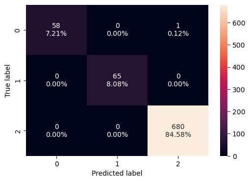

```python
confusion_matrix_sklearn(rf_bow, X_train_bow, y_train_bow)
```

```python
confusion_matrix_sklearn(rf_bow, X_valid_bow, y_valid_bow)
```

[output not shown]

```python
# Predicting on train data
y_pred_train_bow = rf_bow.predict(X_train_bow)

# Predicting on validation data
y_pred_valid_bow = rf_bow.predict(X_valid_bow)
```

**Classification report**

```python
print(classification_report(y_train_bow, y_pred_train_bow))
```

```
              precision    recall  f1-score   support

    NEGATIVE       1.00      0.98      0.99        59
     NEUTRAL       1.00      1.00      1.00        65
    POSITIVE       1.00      1.00      1.00       680

    accuracy                           1.00       804
   macro avg       1.00      0.99      1.00       804
weighted avg       1.00      1.00      1.00       804
```

```python
print(classification_report(y_valid_bow, y_pred_valid_bow))
```

```
              precision    recall  f1-score   support

    NEGATIVE       0.00      0.00      0.00         7
     NEUTRAL       1.00      0.25      0.40         8
    POSITIVE       0.87      1.00      0.93        85

    accuracy                           0.87       100
   macro avg       0.62      0.42      0.44       100
weighted avg       0.82      0.87      0.82       100
```

### Random Forest Model (default with Word2Vec)

```python
# Building the model
rf_bow = RandomForestClassifier(random_state = 42)

# Fitting on train data
rf_bow.fit(X_train_word2vec, y_train_word2vec)
```

```
RandomForestClassifier(random_state=42)
```

**Confusion Matrix**

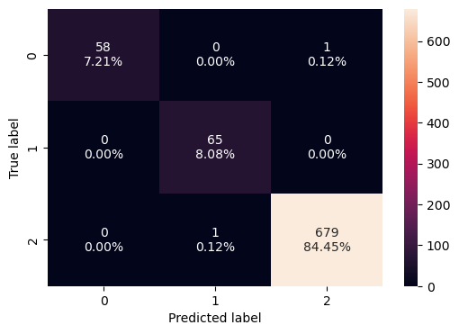

```python
confusion_matrix_sklearn(rf_bow, X_train_word2vec, y_train_word2vec)
```

```python
# Predicting on train data
y_pred_train_word2vec = rf_bow.predict(X_train_word2vec)

# Predicting on validation data
y_pred_valid_word2vec = rf_bow.predict(X_valid_word2vec)
```

**Classification report**

```python
print(classification_report(y_train_word2vec, y_pred_train_word2vec))
```

```
              precision    recall  f1-score   support

    NEGATIVE       1.00      0.98      0.99        59
     NEUTRAL       0.98      1.00      0.99        65
    POSITIVE       1.00      1.00      1.00       680

    accuracy                           1.00       804
   macro avg       0.99      0.99      0.99       804
weighted avg       1.00      1.00      1.00       804
```

```python
print(classification_report(y_valid_word2vec, y_pred_valid_word2vec))
```

```
              precision    recall  f1-score   support

    NEGATIVE       0.23      0.43      0.30         7
     NEUTRAL       0.20      0.25      0.22         8
    POSITIVE       0.92      0.84      0.88        85

    accuracy                           0.76       100
   macro avg       0.45      0.50      0.47       100
weighted avg       0.82      0.76      0.78       100
```

### Random Forest Model (default with GloVe)

```python
# Building the model
rf_bow = RandomForestClassifier(random_state = 42)

# Fitting on train data
rf_bow.fit(X_train_glove, y_train_glove)
```

```
RandomForestClassifier(random_state=42)
```

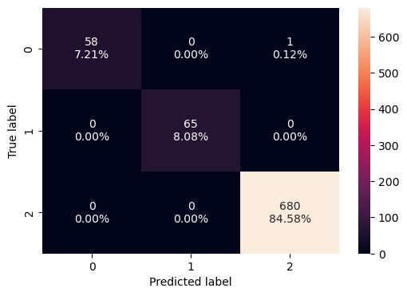

```python
confusion_matrix_sklearn(rf_bow, X_train_glove, y_train_glove)
```

```python
confusion_matrix_sklearn(rf_bow, X_valid_glove, y_valid_glove)
```

[output not shown]

```python
# Predicting on train data
y_pred_train_glove = rf_bow.predict(X_train_glove)

# Predicting on validation data
y_pred_valid_glove = rf_bow.predict(X_valid_glove)
```

**Classification report**

```python
print(classification_report(y_train_glove, y_pred_train_glove))
```

```
              precision    recall  f1-score   support

    NEGATIVE       1.00      0.98      0.99        59
     NEUTRAL       1.00      1.00      1.00        65
    POSITIVE       1.00      1.00      1.00       680

    accuracy                           1.00       804
   macro avg       1.00      0.99      1.00       804
weighted avg       1.00      1.00      1.00       804
```

```python
print(classification_report(y_valid_glove, y_pred_valid_glove))
```

```
              precision    recall  f1-score   support

    NEGATIVE       0.00      0.00      0.00         7
     NEUTRAL       1.00      0.25      0.40         8
    POSITIVE       0.87      1.00      0.93        85

    accuracy                           0.87       100
   macro avg       0.62      0.42      0.44       100
weighted avg       0.82      0.87      0.82       100
```

### Random Forest (with class_weights and BOW)

```python
rf_bow_balanced = RandomForestClassifier(class_weight="balanced", random_state=42)
rf_bow_balanced.fit(X_train_bow, y_train_bow)
```

```
RandomForestClassifier(class_weight='balanced', random_state=42)
```

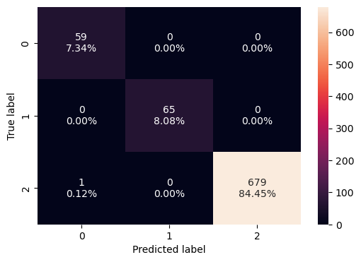

```python
confusion_matrix_sklearn(rf_bow_balanced, X_train_bow, y_train_bow)
```

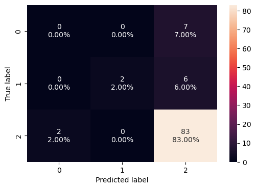

```python
confusion_matrix_sklearn(rf_bow_balanced, X_valid_bow, y_valid_bow)
```

```python
# Predicting on train data
y_pred_train_bow = rf_bow_balanced.predict(X_train_bow)

# Predicting on test data
y_pred_valid_bow = rf_bow_balanced.predict(X_valid_bow)
```

```python
print(classification_report(y_train_bow, y_pred_train_bow))
```

```
              precision    recall  f1-score   support

    NEGATIVE       0.98      1.00      0.99        59
     NEUTRAL       1.00      1.00      1.00        65
    POSITIVE       1.00      1.00      1.00       680

    accuracy                           1.00       804
   macro avg       0.99      1.00      1.00       804
weighted avg       1.00      1.00      1.00       804
```

```python
print(classification_report(y_valid_bow, y_pred_valid_bow))
```

```
              precision    recall  f1-score   support

    NEGATIVE       0.00      0.00      0.00         7
     NEUTRAL       1.00      0.25      0.40         8
    POSITIVE       0.86      0.98      0.92        85

    accuracy                           0.85       100
   macro avg       0.62      0.41      0.44       100
weighted avg       0.81      0.85      0.81       100
```

### Random Forest (with class_weights and Word2Vec)

```python
rf_word2vec_balanced = RandomForestClassifier(class_weight="balanced", random_state=42)
rf_word2vec_balanced.fit(X_train_word2vec, y_train_word2vec)
```

```
RandomForestClassifier(class_weight='balanced', random_state=42)
```

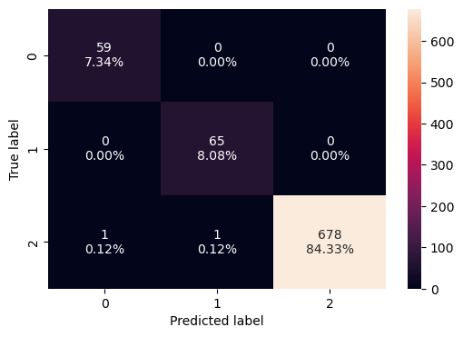

```python
confusion_matrix_sklearn(rf_word2vec_balanced, X_train_word2vec, y_train_word2vec)
```

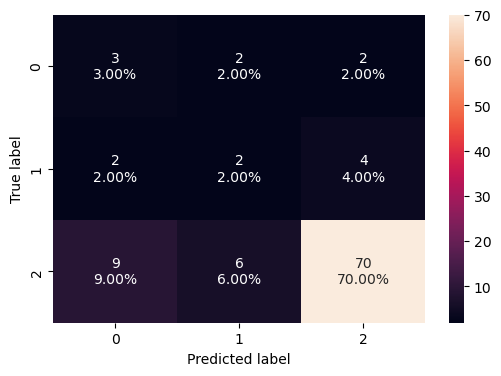

```python
confusion_matrix_sklearn(rf_word2vec_balanced, X_valid_word2vec, y_valid_word2vec)
```

```python
# Predicting on train data
y_pred_train = rf_word2vec_balanced.predict(X_train_word2vec)

# Predicting on test data
y_pred_valid = rf_word2vec_balanced.predict(X_valid_word2vec)
```

```python
print(classification_report(y_train_word2vec, y_pred_train_word2vec))
```

```
              precision    recall  f1-score   support

    NEGATIVE       1.00      0.98      0.99        59
     NEUTRAL       0.98      1.00      0.99        65
    POSITIVE       1.00      1.00      1.00       680

    accuracy                           1.00       804
   macro avg       0.99      0.99      0.99       804
weighted avg       1.00      1.00      1.00       804
```

```python
print(classification_report(y_valid_word2vec, y_pred_valid_word2vec))
```

```
              precision    recall  f1-score   support

    NEGATIVE       0.23      0.43      0.30         7
     NEUTRAL       0.20      0.25      0.22         8
    POSITIVE       0.92      0.84      0.88        85

    accuracy                           0.76       100
   macro avg       0.45      0.50      0.47       100
weighted avg       0.82      0.76      0.78       100
```

### Random Forest (with class_weights and GloVe)

```python
rf_glove_balanced = RandomForestClassifier(class_weight="balanced", random_state=42)
rf_glove_balanced.fit(X_train_glove, y_train_glove)
```

```
RandomForestClassifier(class_weight='balanced', random_state=42)
```

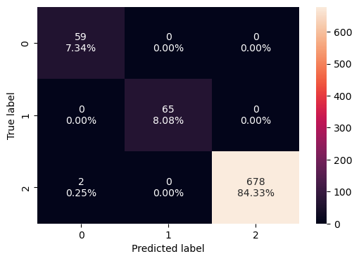

```python
confusion_matrix_sklearn(rf_glove_balanced, X_train_glove, y_train_glove)
```

```python
confusion_matrix_sklearn(rf_glove_balanced, X_valid_glove, y_valid_glove)
```

[output not shown]

```python
# Predicting on train data
y_pred_train = rf_glove_balanced.predict(X_train_glove)

# Predicting on test data
y_pred_valid = rf_glove_balanced.predict(X_valid_glove)
```

```python
print(classification_report(y_train_glove, y_pred_train_glove))
```

```
              precision    recall  f1-score   support

    NEGATIVE       1.00      0.98      0.99        59
     NEUTRAL       1.00      1.00      1.00        65
    POSITIVE       1.00      1.00      1.00       680

    accuracy                           1.00       804
   macro avg       1.00      0.99      1.00       804
weighted avg       1.00      1.00      1.00       804
```

```python
print(classification_report(y_valid_glove, y_pred_valid_glove))
```

```
              precision    recall  f1-score   support

    NEGATIVE       0.00      0.00      0.00         7
     NEUTRAL       1.00      0.25      0.40         8
    POSITIVE       0.87      1.00      0.93        85

    accuracy                           0.87       100
   macro avg       0.62      0.42      0.44       100
weighted avg       0.82      0.87      0.82       100
```

### Random Forest (with hyperparamter tuning and BOW)

```python
# Choose the type of classifier
rf_tuned = RandomForestClassifier(class_weight="balanced", random_state=42)

# defining the hyperparameter grid for tuning
parameters = {
    "max_depth": list(np.arange(4, 15, 2)),
    "max_features": ["sqrt", 0.5, 0.7],
    "min_samples_split": [5, 6, 7],
    "n_estimators": np.arange(30, 110, 10),
}

# defining the type of scoring used to compare parameter combinations
# we need to specify the mechanism of averaging as we have more than 2 target classes
scorer = metrics.make_scorer(metrics.recall_score, average='weighted')

# running the grid search
grid_obj = GridSearchCV(rf_tuned, parameters, scoring=scorer, cv=3, n_jobs=-1)
grid_obj = grid_obj.fit(X_train_bow, y_train_bow)
```

```python
# Creating a new model with the best combination of parameters
rf_bow_tuned = grid_obj.best_estimator_

# Fit the new model to the data
rf_bow_tuned.fit(X_train_bow, y_train_bow)
```

```
RandomForestClassifier(class_weight='balanced', max_depth=4,
                       min_samples_split=5, n_estimators=30, random_state=42)
```

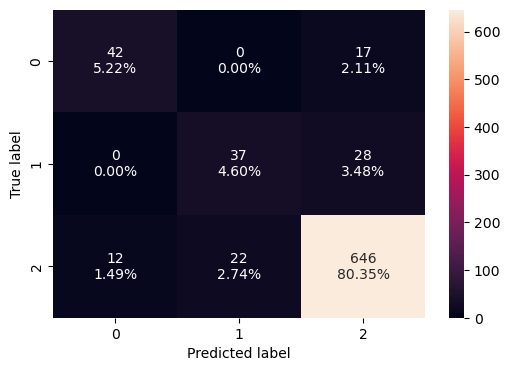

```python
confusion_matrix_sklearn(rf_bow_tuned, X_train_bow, y_train_bow)
```

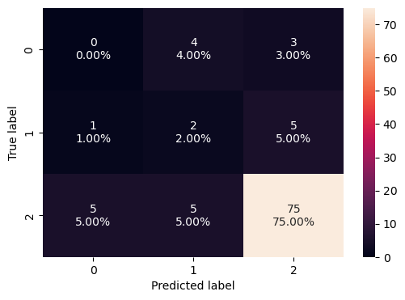

```python
confusion_matrix_sklearn(rf_bow_tuned, X_valid_bow, y_valid_bow)
```

```python
# Predicting on train data
y_pred_train_bow = rf_bow_tuned.predict(X_train_bow)

# Predicting on validation data
y_pred_valid_bow = rf_bow_tuned.predict(X_valid_bow)
```

```python
print(classification_report(y_train_bow, y_pred_train_bow))
```

```
              precision    recall  f1-score   support

    NEGATIVE       0.78      0.71      0.74        59
     NEUTRAL       0.63      0.57      0.60        65
    POSITIVE       0.93      0.95      0.94       680

    accuracy                           0.90       804
   macro avg       0.78      0.74      0.76       804
weighted avg       0.90      0.90      0.90       804
```

```python
print(classification_report(y_valid_bow, y_pred_valid_bow))
```

```
              precision    recall  f1-score   support

    NEGATIVE       0.00      0.00      0.00         7
     NEUTRAL       0.18      0.25      0.21         8
    POSITIVE       0.90      0.88      0.89        85

    accuracy                           0.77       100
   macro avg       0.36      0.38      0.37       100
weighted avg       0.78      0.77      0.78       100
```

### Random Forest (with hyperparameter tuning and Word2Vec)

```python
# Choose the type of classifier
rf_tuned = RandomForestClassifier(class_weight="balanced", random_state=42)

# defining the hyperparameter grid for tuning
parameters = {
    "max_depth": list(np.arange(4, 15, 2)),
    "max_features": ["sqrt", 0.5, 0.7],
    "min_samples_split": [5, 6, 7],
    "n_estimators": np.arange(30, 110, 10),
}

# defining the type of scoring used to compare parameter combinations
# we need to specify the mechanism of averaging as we have more than 2 target classes
scorer = metrics.make_scorer(metrics.recall_score, average='weighted')

# running the grid search
grid_obj = GridSearchCV(rf_tuned, parameters, scoring=scorer, cv=3, n_jobs=-1)
grid_obj = grid_obj.fit(X_train_word2vec, y_train_word2vec)
```

```python
# Creating a new model with the best combination of parameters
rf_word2vec_tuned = grid_obj.best_estimator_

# Fit the new model to the data
rf_word2vec_tuned.fit(X_train_word2vec, y_train_word2vec)
```

```
RandomForestClassifier(class_weight='balanced', max_depth=4,
                       min_samples_split=5, n_estimators=30, random_state=42)
```

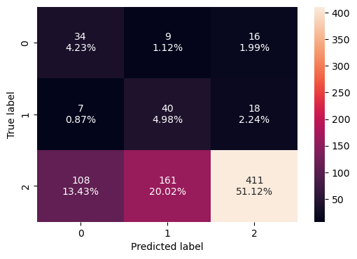

```python
confusion_matrix_sklearn(rf_word2vec_tuned, X_train_word2vec, y_train_word2vec)
```

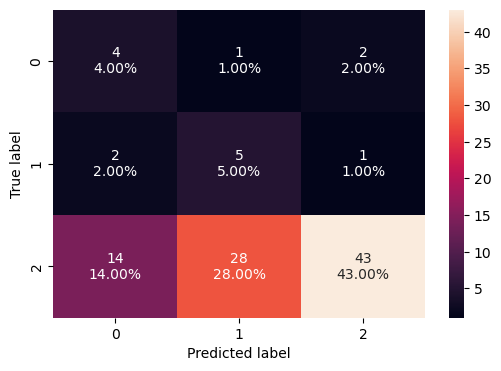

```python
confusion_matrix_sklearn(rf_word2vec_tuned, X_valid_word2vec, y_valid_word2vec)
```

```python
# Predicting on train data
y_pred_train_word2vec = rf_word2vec_tuned.predict(X_train_word2vec)

# Predicting on validation data
y_pred_valid_word2vec = rf_word2vec_tuned.predict(X_valid_word2vec)
```

```python
print(classification_report(y_train_word2vec, y_pred_train_word2vec))
```

```
              precision    recall  f1-score   support

    NEGATIVE       0.23      0.58      0.33        59
     NEUTRAL       0.19      0.62      0.29        65
    POSITIVE       0.92      0.60      0.73       680

    accuracy                           0.60       804
   macro avg       0.45      0.60      0.45       804
weighted avg       0.81      0.60      0.67       804
```

```python
print(classification_report(y_valid_word2vec, y_pred_valid_word2vec))
```

```
              precision    recall  f1-score   support

    NEGATIVE       0.20      0.57      0.30         7
     NEUTRAL       0.15      0.62      0.24         8
    POSITIVE       0.93      0.51      0.66        85

    accuracy                           0.52       100
   macro avg       0.43      0.57      0.40       100
weighted avg       0.82      0.52      0.60       100
```

### Random Forest (with hyperparametertuning and GloVe)

```python
# Choose the type of classifier
rf_tuned = RandomForestClassifier(class_weight="balanced", random_state=42)

# defining the hyperparameter grid for tuning
parameters = {
    "max_depth": list(np.arange(4, 15, 2)),
    "max_features": ["sqrt", 0.5, 0.7],
    "min_samples_split": [5, 6, 7],
    "n_estimators": np.arange(30, 110, 10),
}

# defining the type of scoring used to compare parameter combinations
# we need to specify the mechanism of averaging as we have more than 2 target classes
scorer = metrics.make_scorer(metrics.recall_score, average='weighted')

# running the grid search
grid_obj = GridSearchCV(rf_tuned, parameters, scoring=scorer, cv=3, n_jobs=-1)
grid_obj = grid_obj.fit(X_train_glove, y_train_glove)
```

```python
# Creating a new model with the best combination of parameters
rf_glove_tuned = grid_obj.best_estimator_

# Fit the new model to the data
rf_glove_tuned.fit(X_train_glove, y_train_glove)
```

```
RandomForestClassifier(class_weight='balanced', max_depth=4,
                       min_samples_split=5, n_estimators=30, random_state=42)
```

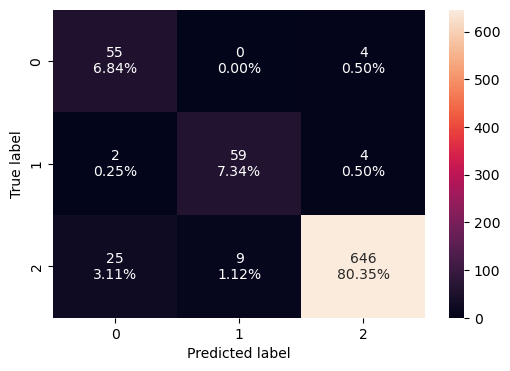

```python
#Printing the confusion matrix
confusion_matrix_sklearn(rf_glove_tuned, X_train_glove, y_train_glove)
```

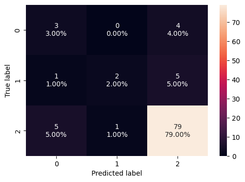

```python
#Printing the confusion matrix
confusion_matrix_sklearn(rf_glove_tuned, X_valid_glove, y_valid_glove)
```

```python
# Predicting on train data
y_pred_train_glove = rf_glove_tuned.predict(X_train_glove)

# Predicting on validation data
y_pred_valid_glove = rf_glove_tuned.predict(X_valid_glove)
```

```python
#Printing
print(classification_report(y_train_glove, y_pred_train_glove))
```

```
              precision    recall  f1-score   support

    NEGATIVE       0.67      0.93      0.78        59
     NEUTRAL       0.87      0.91      0.89        65
    POSITIVE       0.99      0.95      0.97       680

    accuracy                           0.95       804
   macro avg       0.84      0.93      0.88       804
weighted avg       0.95      0.95      0.95       804
```

```python
print(classification_report(y_valid_glove, y_pred_valid_glove))
```

```
              precision    recall  f1-score   support

    NEGATIVE       0.33      0.43      0.38         7
     NEUTRAL       0.67      0.25      0.36         8
    POSITIVE       0.90      0.93      0.91        85

    accuracy                           0.84       100
   macro avg       0.63      0.54      0.55       100
weighted avg       0.84      0.84      0.83       100
```

# Model Testing

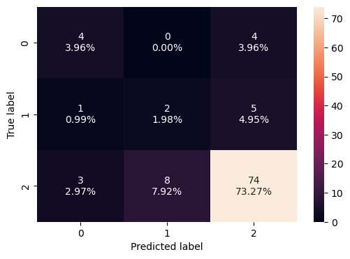

```python
confusion_matrix_sklearn(rf_bow_tuned, X_test_bow, y_test_bow)
```

```python
# Predicting on test data
y_pred_test_bow = rf_bow_tuned.predict(X_test_bow)
```

```python
print(classification_report(y_test_bow, y_pred_test_bow))
```

```
              precision    recall  f1-score   support

    NEGATIVE       0.50      0.50      0.50         8
     NEUTRAL       0.20      0.25      0.22         8
    POSITIVE       0.89      0.87      0.88        85

    accuracy                           0.79       101
   macro avg       0.53      0.54      0.53       101
weighted avg       0.81      0.79      0.80       101
```